# Dist-over-time-by-site

Dan Spakowicz

6/22/2022

From Xin:

> As we discussed, there is the raw data for our figure 3b. It can be loaded into R by “load(path_to_the_file)”. The variable you need will be “dist” which is the bray Curtis distance, and “diffdays” which is the time interval. We kept all other variables like batch or season so you can decide if this is something important in your model. There are two questions we want to answer in figure 3, 1) if the stool microbiome are the most stable one across time? 2) when one body site is not so stable (over time), does another body site also being unstable? We answered this a little bit in figure 3c, but would appreciate if you have additional ways to test or model this.

```r
files <- list.files("../data/", full.names = TRUE)
files
```

```
## [1] "../data/raw.dist.RData"  "../data/temp_data_nasal"
## [3] "../data/temp_data_oral"  "../data/temp_data_skin"
## [5] "../data/temp_data_stool"
```

```r
load(files[1])
load(files[2])
load(files[3])
load(files[4])
load(files[5])
```

Initial version

```r
all <- bind_rows(temp_data_nasal,
                 temp_data_oral,
                 temp_data_skin,
                 temp_data_stool)
head(all)
```

```
## # A tibble: 6 x 21
##   subject_id1 subject_id2 sample_id1 sample_id2 date1      date2       dist
##   <chr>       <chr>       <chr>      <chr>      <date>     <date>     <dbl>
## 1 69-001      69-001      69-001-44  69-001-48  2012-07-27 2012-11-01 0.902
## 2 69-001      69-001      69-001-44  69-001-49  2012-07-27 2012-11-12 0.569
## 3 69-001      69-001      69-001-44  69-001-53  2012-07-27 2013-01-22 0.961
## 4 69-001      69-001      69-001-44  69-001-54  2012-07-27 2013-01-24 0.603
## 5 69-001      69-001      69-001-44  69-001-55  2012-07-27 2013-01-30 0.839
## 6 69-001      69-001      69-001-44  69-001-56  2012-07-27 2013-02-06 0.566
## # ... with 14 more variables: batch1 <chr>, batch2 <chr>, type <chr>,
## #   dataset <chr>, batch_type <chr>, diffdays <int>, season1 <chr>,
## #   season2 <chr>, season_type <chr>, number <int>, cor <dbl>, p_value <dbl>,
## #   p_value_adjust <dbl>, name <chr>
```

Updated dataset with more rows

```r
all2 <- bind_rows(nasal_braydist_by_sample,
                  oral_braydist_by_sample,
                  skin_braydist_by_sample,
                  stool_braydist_by_sample)

head(all2)
```

```
## # A tibble: 6 x 16
##   subject_id1 subject_id2 sample_id1   sample_id2   date1      date2       dist
##   <chr>       <chr>       <chr>        <chr>        <date>     <date>     <dbl>
## 1 70-1004     70-1004     70-1004-1014 70-1004-05   2013-11-13 2013-09-18 0.896
## 2 70-1004     70-1004     70-1004-1014 70-1004-07   2013-11-13 2014-02-12 0.633
## 3 70-1004     70-1004     70-1004-1014 70-1004-1011 2013-11-13 2013-11-01 0.789
## 4 70-1004     70-1004     70-1004-1014 70-1004-1012 2013-11-13 2013-11-04 0.392
## 5 70-1004     70-1004     70-1004-1014 70-1004-08   2013-11-13 2014-05-14 0.861
## 6 70-1004     70-1004     70-1004-1014 70-1004-09   2013-11-13 2014-08-19 0.800
## # ... with 9 more variables: batch1 <chr>, batch2 <chr>, type <chr>,
## #   dataset <chr>, batch_type <chr>, diffdays <int>, season1 <chr>,
## #   season2 <chr>, season_type <chr>
```

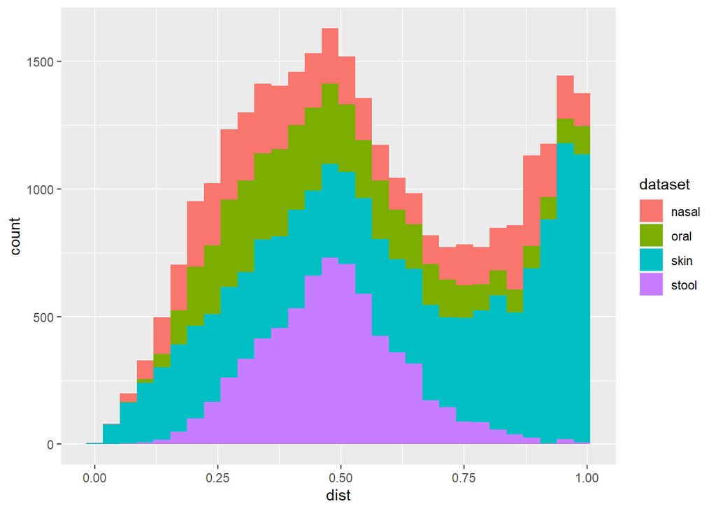

```r
all %>%
  ggplot(aes(x = dist)) +
  geom_histogram(aes(fill = dataset))
```

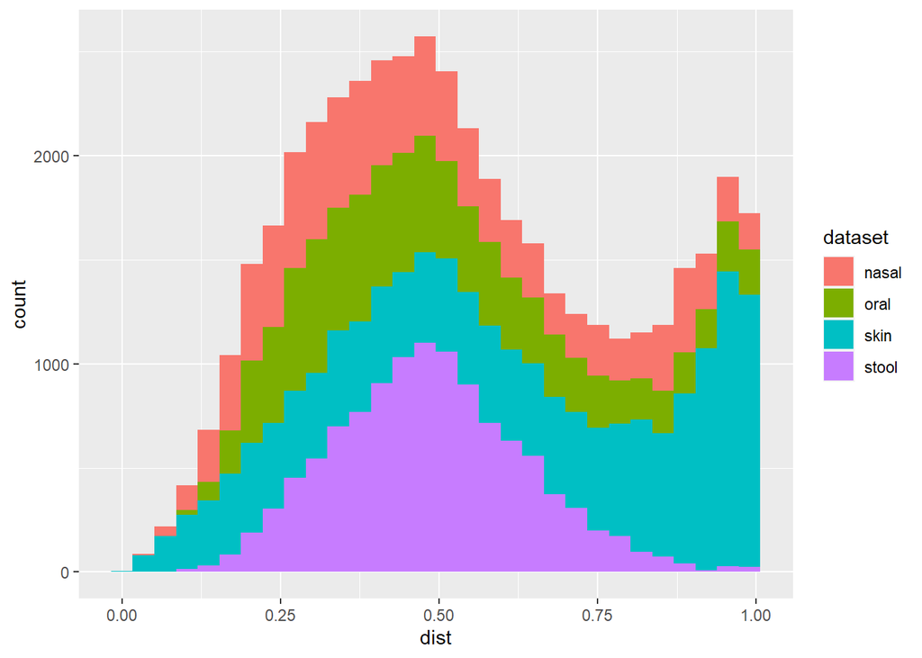

```r
all2 %>%
  ggplot(aes(x = dist)) +
  geom_histogram(aes(fill = dataset))
```

```r
all2v2 <-
  all2%>%
  mutate(dist.0.99 = if_else(dist == 1,
                             true = 0.9999999999999999,
                             false = dist),
         dist_log = log10(dist.0.99),
         dist_neglogRec = -log10(1 - dist.0.99),
         dist_logneglogRec = log10(dist_neglogRec),
         dist_sqrt = sqrt(dist),
         dist_logit = log(dist.0.99 / (1-dist.0.99)),
         dist_asin = asin(sqrt(dist))
         )

# all.trans$dist[all.trans$dist == 1] <- 0.9999999999999999
#
# all.trans <- all.trans %>% mutate(dist_trans = log10(-log10(1-dist)))
```

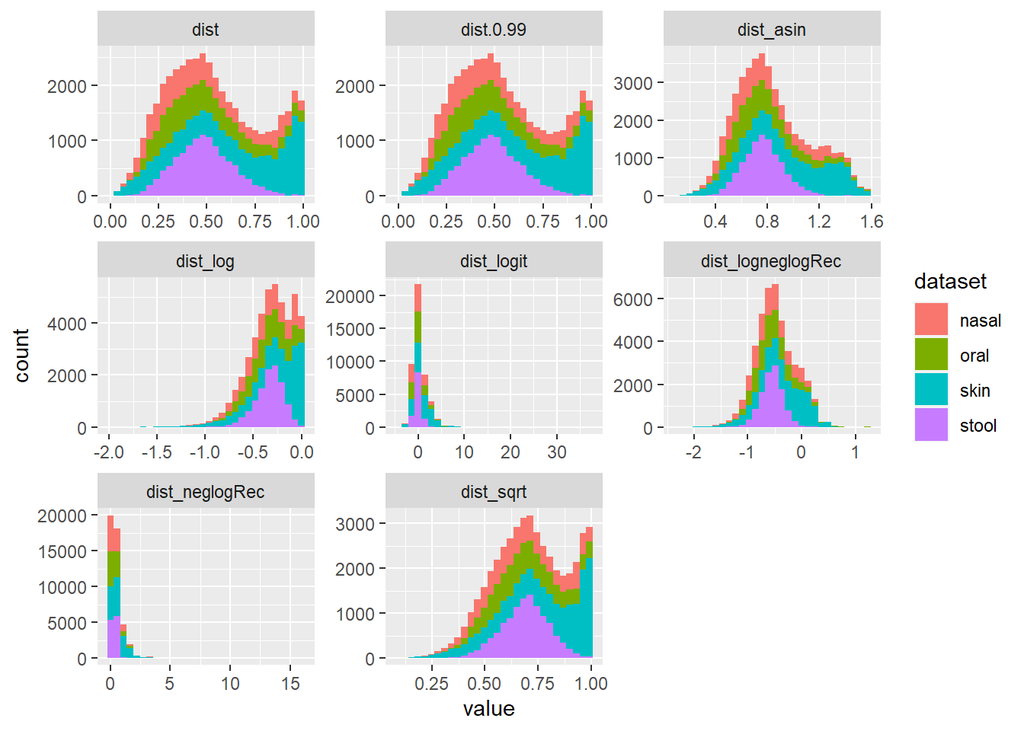

```r
all2v2 %>%
  select(dataset, contains("dist")) %>%
  gather(-dataset, key = "measure", value = "value") %>%
  ggplot(aes(x = value)) +
  geom_histogram(aes(fill = dataset)) +
  facet_wrap(~measure, scales = "free")
```

The `dist_logneglogRec` variable appears the most normally distributed.

# Modeling with untransformed data

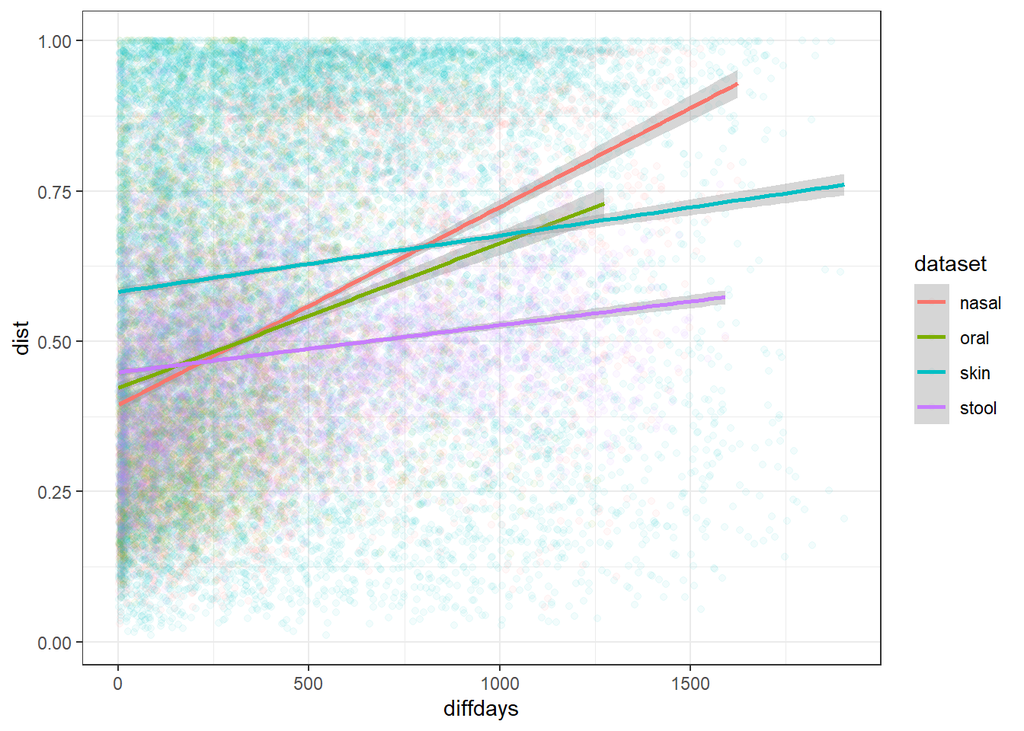

```r
all %>%
  ggplot(aes(x = diffdays, y = dist)) +
  geom_point(aes(color = dataset), alpha = 0.05) +
  stat_smooth(method = "lm", aes(group = dataset, color = dataset)) +
  theme_bw()
```

Simple regression with an interaction term for source of the microbes.

```r
m0 <- lm(dist ~ diffdays * dataset,
         data = all)

summary(m0)
```

```
##
## Call:
## lm(formula = dist ~ diffdays * dataset, data = all)
##
## Residuals:
##      Min       1Q   Median       3Q      Max
## -0.71572 -0.16817 -0.00393  0.19131  0.58080
##
## Coefficients:
##                         Estimate Std. Error t value Pr(>|t|)
## (Intercept)            3.938e-01  5.147e-03  76.521  < 2e-16 ***
## diffdays               3.295e-04  9.355e-06  35.217  < 2e-16 ***
## datasetoral            2.864e-02  7.266e-03   3.941 8.13e-05 ***
## datasetskin            1.884e-01  6.192e-03  30.422  < 2e-16 ***
## datasetstool           5.429e-02  6.901e-03   7.868 3.74e-15 ***
## diffdays:datasetoral  -8.885e-05  1.760e-05  -5.049 4.47e-07 ***
## diffdays:datasetskin  -2.357e-04  1.076e-05 -21.896  < 2e-16 ***
## diffdays:datasetstool -2.508e-04  1.258e-05 -19.935  < 2e-16 ***
## ---
## Signif. codes:  0 '***' 0.001 '**' 0.01 '*' 0.05 '.' 0.1 ' ' 1
##
## Residual standard error: 0.2374 on 29816 degrees of freedom
## Multiple R-squared:  0.1257, Adjusted R-squared:  0.1255
## F-statistic: 612.4 on 7 and 29816 DF,  p-value: < 2.2e-16
```

Now check a model that takes into account the repeated measures for each individual.

```r
m1 <- lme(dist ~ diffdays * dataset,
          random = ~1|subject_id1,
         data = all)
summary(m1)
```

```
## Linear mixed-effects model fit by REML
##   Data: all
##         AIC       BIC   logLik
##   -1603.475 -1520.447 811.7373
##
## Random effects:
##  Formula: ~1 | subject_id1
##         (Intercept)  Residual
## StdDev:  0.05971215 0.2346079
##
## Fixed effects:  dist ~ diffdays * dataset
##                            Value   Std.Error    DF   t-value p-value
## (Intercept)            0.4374558 0.011382040 29777  38.43386  0.0000
## diffdays               0.0003275 0.000009431 29777  34.72746  0.0000
## datasetoral            0.0087163 0.007627948 29777   1.14269  0.2532
## datasetskin            0.1755980 0.006574699 29777  26.70815  0.0000
## datasetstool           0.0190309 0.007416860 29777   2.56590  0.0103
## diffdays:datasetoral  -0.0000835 0.000017717 29777  -4.71155  0.0000
## diffdays:datasetskin  -0.0002365 0.000010817 29777 -21.86086  0.0000
## diffdays:datasetstool -0.0002228 0.000012649 29777 -17.61792  0.0000
##  Correlation:
##                       (Intr) dffdys dtstrl dtstsk dtstst dffdys:dtstr
## diffdays              -0.348
## datasetoral           -0.336  0.533
## datasetskin           -0.402  0.630  0.602
## datasetstool          -0.357  0.570  0.511  0.616
## diffdays:datasetoral   0.192 -0.533 -0.739 -0.345 -0.304
## diffdays:datasetskin   0.316 -0.866 -0.474 -0.766 -0.491  0.465
## diffdays:datasetstool  0.275 -0.742 -0.397 -0.470 -0.767  0.394
##                       dffdys:dtstsk
## diffdays
## datasetoral
## datasetskin
## datasetstool
## diffdays:datasetoral
## diffdays:datasetskin
## diffdays:datasetstool  0.644
##
## Standardized Within-Group Residuals:
##          Min           Q1          Med           Q3          Max
## -3.066753707 -0.704577321 -0.004061539  0.792478846  2.615598720
##
## Number of Observations: 29824
## Number of Groups: 40
```

# Modeling with transformed data

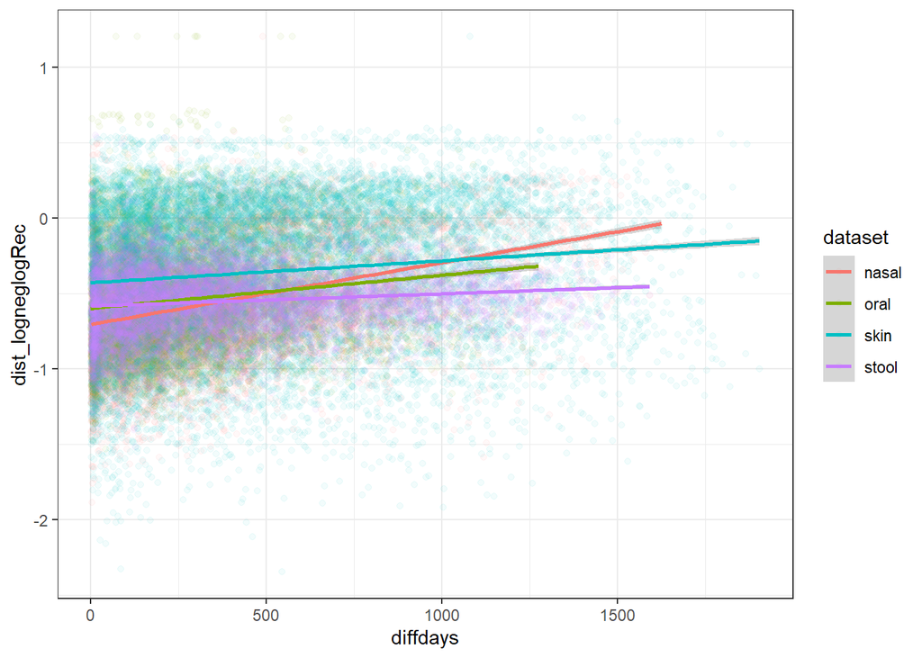

```r
all2v2 %>%
  ggplot(aes(x = diffdays, y = dist_logneglogRec)) +
  geom_point(aes(color = dataset), alpha = 0.05) +
  stat_smooth(method = "lm", aes(group = dataset, color = dataset)) +
  theme_bw()
```

Simple regression with an interaction term for source of the microbes.

```r
m2 <- lm(dist_logneglogRec ~ diffdays * dataset,
         data = all2v2)

summary(m2)
```

```
##
## Call:
## lm(formula = dist_logneglogRec ~ diffdays * dataset, data = all2v2)
##
## Residuals:
##      Min       1Q   Median       3Q      Max
## -1.99790 -0.21619  0.00049  0.23071  1.78542
##
## Coefficients:
##                         Estimate Std. Error  t value Pr(>|t|)
## (Intercept)           -7.053e-01  5.495e-03 -128.349   <2e-16 ***
## diffdays               4.106e-04  1.158e-05   35.469   <2e-16 ***
## datasetoral            1.072e-01  7.861e-03   13.635   <2e-16 ***
## datasetskin            2.770e-01  7.186e-03   38.550   <2e-16 ***
## datasetstool           1.223e-01  7.498e-03   16.305   <2e-16 ***
## diffdays:datasetoral  -1.909e-04  1.915e-05   -9.971   <2e-16 ***
## diffdays:datasetskin  -2.651e-04  1.370e-05  -19.352   <2e-16 ***
## diffdays:datasetstool -3.292e-04  1.563e-05  -21.066   <2e-16 ***
## ---
## Signif. codes:  0 '***' 0.001 '**' 0.01 '*' 0.05 '.' 0.1 ' ' 1
##
## Residual standard error: 0.3527 on 45447 degrees of freedom
## Multiple R-squared:  0.09871,    Adjusted R-squared:  0.09857
## F-statistic: 711.1 on 7 and 45447 DF,  p-value: < 2.2e-16
```

Now check a model that takes into account the repeated measures for each individual.

```r
m3 <- lme(dist_logneglogRec ~ diffdays * dataset,
          random = ~1|subject_id1,
         data = all2v2)

summary(m3)
```

```
## Linear mixed-effects model fit by REML
##   Data: all2v2
##        AIC      BIC   logLik
##   33889.79 33977.04 -16934.9
##
## Random effects:
##  Formula: ~1 | subject_id1
##         (Intercept)  Residual
## StdDev:  0.06285972 0.3501942
##
## Fixed effects:  dist_logneglogRec ~ diffdays * dataset
##                            Value   Std.Error    DF   t-value p-value
## (Intercept)           -0.6957960 0.009777743 45374 -71.16121       0
## diffdays               0.0004264 0.000011700 45374  36.44397       0
## datasetoral            0.1088180 0.007890371 45374  13.79124       0
## datasetskin            0.2866250 0.007261361 45374  39.47262       0
## datasetstool           0.1225921 0.007494230 45374  16.35820       0
## diffdays:datasetoral  -0.0002003 0.000019189 45374 -10.43731       0
## diffdays:datasetskin  -0.0002790 0.000013683 45374 -20.38783       0
## diffdays:datasetstool -0.0003277 0.000015538 45374 -21.09163       0
##  Correlation:
##                       (Intr) dffdys dtstrl dtstsk dtstst dffdys:dtstr
## diffdays              -0.414
## datasetoral           -0.393  0.514
## datasetskin           -0.431  0.571  0.534
## datasetstool          -0.406  0.550  0.514  0.557
## diffdays:datasetoral   0.246 -0.596 -0.754 -0.350 -0.337
## diffdays:datasetskin   0.356 -0.841 -0.441 -0.755 -0.465  0.508
## diffdays:datasetstool  0.312 -0.731 -0.388 -0.419 -0.754  0.445
##                       dffdys:dtstsk
## diffdays
## datasetoral
## datasetskin
## datasetstool
## diffdays:datasetoral
## diffdays:datasetskin
## diffdays:datasetstool  0.623
##
## Standardized Within-Group Residuals:
##          Min           Q1          Med           Q3          Max
## -5.668680601 -0.612107827  0.006452992  0.646700912  5.196752816
##
## Number of Observations: 45455
## Number of Groups: 74
```

```r
# Changed the optimizer, but it didn't really matter. There are convergence
# warnings with all of the optimizers but the summary convergence codes are OK
m4 <- lmer(dist_logneglogRec ~ -1 + dataset:diffdays +
             (1 | subject_id1) + ( 1 + dataset | subject_id1),
           control = lmerControl(optimizer = "Nelder_Mead"),
          data = all2v2)
summary(m4)
```

```
## Linear mixed model fit by REML. t-tests use Satterthwaite's method [
## lmerModLmerTest]
## Formula: dist_logneglogRec ~ -1 + dataset:diffdays + (1 | subject_id1) +
##     (1 + dataset | subject_id1)
##    Data: all2v2
## Control: lmerControl(optimizer = "Nelder_Mead")
##
## REML criterion at convergence: 31955.2
##
## Scaled residuals:
##     Min      1Q  Median      3Q     Max
## -5.7169 -0.5931  0.0157  0.6405  5.2374
##
## Random effects:
##  Groups        Name         Variance Std.Dev. Corr
##  subject_id1   (Intercept)  0.01268  0.1126
##  subject_id1.1 (Intercept)  0.55613  0.7457
##                datasetoral  0.06840  0.2615   -0.80
##                datasetskin  0.16707  0.4087   -0.96  0.79
##                datasetstool 0.04322  0.2079   -0.82  0.75  0.84
##  Residual                   0.11586  0.3404
## Number of obs: 45455, groups:  subject_id1, 74
##
## Fixed effects:
##                        Estimate Std. Error        df t value Pr(>|t|)
## datasetnasal:diffdays 3.508e-04  1.200e-05 2.594e+04   29.23   <2e-16 ***
## datasetoral:diffdays  2.175e-04  1.544e-05 1.625e+04   14.08   <2e-16 ***
## datasetskin:diffdays  1.552e-04  7.260e-06 2.066e+04   21.38   <2e-16 ***
## datasetstool:diffdays 1.234e-04  1.066e-05 2.056e+04   11.57   <2e-16 ***
## ---
## Signif. codes:  0 '***' 0.001 '**' 0.01 '*' 0.05 '.' 0.1 ' ' 1
##
## Correlation of Fixed Effects:
##             dtstn: dtstr: dtstsk:
## dtstrl:dffd 0.015
## dtstskn:dff 0.007  0.009
## dtststl:dff 0.021  0.013  0.011
## optimizer (Nelder_Mead) convergence code: 0 (OK)
## Model failed to converge with max|grad| = 0.214323 (tol = 0.002, component 1)
```

```r
lrtest(m3, m4)
```

```
## Likelihood ratio test
##
## Model 1: dist_logneglogRec ~ diffdays * dataset
## Model 2: dist_logneglogRec ~ -1 + dataset:diffdays + (1 | subject_id1) +
##     (1 + dataset | subject_id1)
##   #Df LogLik Df  Chisq Pr(>Chisq)
## 1  10 -16935
## 2  16 -15978  6 1914.6  < 2.2e-16 ***
## ---
## Signif. codes:  0 '***' 0.001 '**' 0.01 '*' 0.05 '.' 0.1 ' ' 1
```

```r
m5 <- lmer(dist_logneglogRec ~ diffdays:dataset + (1 | subject_id1) + ( 1 + dataset | subject_id1),
          data = all2v2)
summary(m5)
```

```
## Linear mixed model fit by REML. t-tests use Satterthwaite's method [
## lmerModLmerTest]
## Formula: dist_logneglogRec ~ diffdays:dataset + (1 | subject_id1) + (1 +
##     dataset | subject_id1)
##    Data: all2v2
##
## REML criterion at convergence: 31757.6
##
## Scaled residuals:
##     Min      1Q  Median      3Q     Max
## -5.7157 -0.5929  0.0162  0.6417  5.2360
##
## Random effects:
##  Groups        Name         Variance  Std.Dev. Corr
##  subject_id1   (Intercept)  8.508e-06 0.002917
##  subject_id1.1 (Intercept)  5.855e-02 0.241965
##                datasetoral  6.901e-02 0.262700 -0.87
##                datasetskin  1.638e-01 0.404710 -0.94  0.77
##                datasetstool 4.299e-02 0.207336 -0.89  0.73  0.83
##  Residual                   1.159e-01 0.340399
## Number of obs: 45455, groups:  subject_id1, 74
##
## Fixed effects:
##                         Estimate Std. Error         df t value Pr(>|t|)
## (Intercept)           -5.300e-01  7.211e-03  5.563e+01  -73.50   <2e-16 ***
## diffdays:datasetnasal  3.457e-04  1.206e-05  3.272e+04   28.67   <2e-16 ***
## diffdays:datasetoral   2.188e-04  1.543e-05  1.724e+04   14.18   <2e-16 ***
## diffdays:datasetskin   1.598e-04  7.344e-06  3.961e+04   21.75   <2e-16 ***
## diffdays:datasetstool  1.232e-04  1.065e-05  2.011e+04   11.57   <2e-16 ***
## ---
## Signif. codes:  0 '***' 0.001 '**' 0.01 '*' 0.05 '.' 0.1 ' ' 1
##
## Correlation of Fixed Effects:
##               (Intr) dffdys:dtstn dffdys:dtstr dffdys:dtstsk
## dffdys:dtstn  -0.063
## dffdys:dtstr  -0.188  0.009
## dffdys:dtstsk -0.140 -0.008        0.010
## dffdys:dtstst -0.123  0.019        0.010        0.012
## optimizer (nloptwrap) convergence code: 0 (OK)
## Model failed to converge with max|grad| = 0.00349768 (tol = 0.002, component 1)
```

```r
lrtest(m4, m5)
```

```
## Likelihood ratio test
##
## Model 1: dist_logneglogRec ~ -1 + dataset:diffdays + (1 | subject_id1) +
##     (1 + dataset | subject_id1)
## Model 2: dist_logneglogRec ~ diffdays:dataset + (1 | subject_id1) + (1 +
##     dataset | subject_id1)
##   #Df LogLik Df  Chisq Pr(>Chisq)
## 1  16 -15978
## 2  17 -15879  1 197.66  < 2.2e-16 ***
## ---
## Signif. codes:  0 '***' 0.001 '**' 0.01 '*' 0.05 '.' 0.1 ' ' 1
```

```r
m6 <- lmer(dist_logneglogRec ~ diffdays:dataset + ( 1 + dataset | subject_id1),
          data = all2v2)
summary(m6)
```

```
## Linear mixed model fit by REML. t-tests use Satterthwaite's method [
## lmerModLmerTest]
## Formula: dist_logneglogRec ~ diffdays:dataset + (1 + dataset | subject_id1)
##    Data: all2v2
##
## REML criterion at convergence: 31757.6
##
## Scaled residuals:
##     Min      1Q  Median      3Q     Max
## -5.7157 -0.5929  0.0162  0.6417  5.2360
##
## Random effects:
##  Groups      Name         Variance Std.Dev. Corr
##  subject_id1 (Intercept)  0.05853  0.2419
##              datasetoral  0.06900  0.2627   -0.87
##              datasetskin  0.16376  0.4047   -0.94  0.77
##              datasetstool 0.04298  0.2073   -0.89  0.73  0.83
##  Residual                 0.11587  0.3404
## Number of obs: 45455, groups:  subject_id1, 74
##
## Fixed effects:
##                         Estimate Std. Error         df t value Pr(>|t|)
## (Intercept)           -5.300e-01  7.211e-03  5.564e+01  -73.50   <2e-16 ***
## diffdays:datasetnasal  3.457e-04  1.206e-05  3.272e+04   28.67   <2e-16 ***
## diffdays:datasetoral   2.188e-04  1.543e-05  1.724e+04   14.18   <2e-16 ***
## diffdays:datasetskin   1.598e-04  7.344e-06  3.961e+04   21.75   <2e-16 ***
## diffdays:datasetstool  1.232e-04  1.065e-05  2.011e+04   11.57   <2e-16 ***
## ---
## Signif. codes:  0 '***' 0.001 '**' 0.01 '*' 0.05 '.' 0.1 ' ' 1
##
## Correlation of Fixed Effects:
##               (Intr) dffdys:dtstn dffdys:dtstr dffdys:dtstsk
## dffdys:dtstn  -0.063
## dffdys:dtstr  -0.188  0.009
## dffdys:dtstsk -0.140 -0.008        0.010
## dffdys:dtstst -0.123  0.019        0.010        0.012
## optimizer (nloptwrap) convergence code: 0 (OK)
## Model failed to converge with max|grad| = 0.00231844 (tol = 0.002, component 1)
```

```r
lrtest(m5, m6)
```

```
## Likelihood ratio test
##
## Model 1: dist_logneglogRec ~ diffdays:dataset + (1 | subject_id1) + (1 +
##     dataset | subject_id1)
## Model 2: dist_logneglogRec ~ diffdays:dataset + (1 + dataset | subject_id1)
##   #Df LogLik Df Chisq Pr(>Chisq)
## 1  17 -15879
## 2  16 -15879 -1     0      0.998
```